# Simulating the effect of missed or delayed timepoints around Tmax on noncompartmental analysis parameters

Jerry Hu

2026-09-25

← PK/PD Home Page

# 1 Summary

**Background.** Real blood-sampling schedules deviate from plan. A sample near the peak can be missed, or drawn later than planned. The objective is to quantify how much a single missed or delayed sample around Tmax biases the key NCA exposure parameters (Cmax, AUC0-t, AUC0-inf) relative to a planned schedule; the secondary objective is to characterize how simulated variability affects Cmax and Tmax.

**Methods.** Simulation, NCA, tables and figures, and the statistical analysis were all conducted in R. Concentration–time data were simulated from three one-compartment oral pharmacokinetic models with differing absorption and elimination rates, from 0 to 24 h after a single oral dose (20 subjects per model). The typical time of peak was held at about 0.5 h, so the three profiles differ mainly in peak shape, from a flat plateau to a sharp peak; between-subject variability moves each subject’s own peak time around that. Three sampling schedules were applied to the same subjects: a planned 13-sample schedule, an omission schedule with the near-peak sample dropped, and a delay schedule with that sample drawn 10 minutes late. NCA derived Cmax, AUC0-t and AUC0-inf from each schedule. Each deviating schedule was then compared with the planned schedule in the same subjects, as a paired geometric mean ratio with a 90% confidence interval on the log scale, and the spread of the individual ratios was summarised. The planned schedule was also compared with each subject’s predicted value: the same NCA applied to their individual predicted profile, without residual error.

**Results.** A missed near-peak sample lowered Cmax by 2.6-7.7% across shapes (most in the sharply peaked profile), while it lowered AUC0-t by 0.1-2.5% and AUC0-inf by 0.2-2.5%. A delayed sample, analysed at its actual draw time, changed Cmax by −4.2% to +1.6% and both AUCs by −1.5% to +0.1%. Individual subjects deviated more than the mean: the lowest single-subject Cmax ratio after a missed sample was 74.7% of planned. The planned schedule itself overstated Cmax by 4.3-4.9% relative to the predicted value, from residual variability alone. Across both deviations the largest change was in Cmax; a single missed or delayed near-peak sample moved NCA exposure only slightly on average.

# 2 Background

Blood-sampling schedules in clinical pharmacokinetics are finite and planned in advance. Noncompartmental analysis (NCA) of those samples yields Cmax, Tmax and the areas under the curve (AUC), which feed exposure and labelling decisions. Unplanned deviations disturb those schedules: a sample is missed, or a sample is drawn late. Sampling near the peak matters most for Cmax and Tmax, because those two estimates depend on whether the measurements capture the maximum at all; the sharper the peak, the more sensitive they are to a gap around it.

**Objectives.**

- *Primary:* Quantify how much a single missed or delayed sample around Tmax biases the key NCA exposure parameters (Cmax, AUC0-t, AUC0-inf) relative to a planned schedule.
- *Secondary:* Characterize how simulated variability affects Cmax and Tmax.

# 3 Methods

All steps were conducted in R version 4.5.2. The design crosses three profile shapes (Plateau, Moderate, Peaked) with four concentration analysis sets: Predicted (between-subject variability, no residual error), Planned, Omission and Delay.

R packages used at each analysis step.

| Analysis step | R tools and packages |
| --- | --- |
| Concentration-time simulation | mrgsolve |
| Data preparation | dplyr, tidyr |
| Noncompartmental analysis | PKNCA |
| Statistical analysis | Base R and stats |
| Figures, tables, and report | ggplot2, knitr, kableExtra |

## 3.1 Simulation

### 3.1.1 Simulation model

The data were simulated with the R package `mrgsolve`. The structural model is one compartment with first-order oral absorption: a dosing compartment (GUT) feeds a central compartment (CENT), parameterised by absorption rate ka, clearance CL, and volume V. The model is shown below:

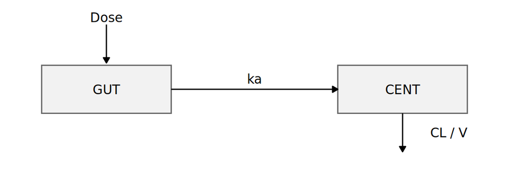

One-compartment model with first-order oral absorption.

$$\frac{dA_{\mathrm{GUT}}}{dt} = -k_a\,A_{\mathrm{GUT}}, \qquad
\frac{dA_{\mathrm{CENT}}}{dt} = k_a\,A_{\mathrm{GUT}} -
\frac{CL}{V}\,A_{\mathrm{CENT}}, \qquad
C = \frac{A_{\mathrm{CENT}}}{V}.$$

where $A_{\mathrm{GUT}}$ is the amount of drug in the absorption (gut) compartment, $A_{\mathrm{CENT}}$ the amount in the central compartment, $k_a$ the first-order absorption rate constant, $CL$ the clearance, $V$ the central volume of distribution, and $C$ the plasma concentration ($C = A_{\mathrm{CENT}}/V$).

The model is defined in `mrgsolve`. The `$OMEGA` and `$SIGMA` blocks carry the between-subject and residual variability described below:

```r
# --- data-generating model -------------------------------------------
# OMEGA = log(1 + CV^2) for 30% log-normal CV ≈ 0.0862 (variance scale).
# SIGMA = (0.10)^2 = 0.01 for 10% proportional RUV (variance scale).
.model_code <- '
$PARAM
// Placeholders only: every run overrides these with the profile it simulates
// (see the typical parameters below).
TVKA = 5.2, TVCL = 25, TVV = 50

$CMT GUT CENT

$OMEGA @labels ETA_KA ETA_CL ETA_V
0.0862 0.0862 0.0862

$SIGMA @labels PROP
0.01

$PK
double KA = TVKA * exp(ETA_KA);
double CL = TVCL * exp(ETA_CL);
double V  = TVV  * exp(ETA_V);

$ODE
dxdt_GUT  = -KA * GUT;
dxdt_CENT =  KA * GUT - (CL/V) * CENT;

$ERROR
double IPRED = CENT / V;
double DV = IPRED * (1 + PROP);

$CAPTURE IPRED DV KA CL V
'

mod <- mrgsolve::mcode("oral_1cmt", .model_code, quiet = TRUE)
```

**Between-subject variability** is log-normal on ka, CL and V:

$$\theta_i = \theta_{\mathrm{typ}}\,e^{\eta_{\theta,i}}, \qquad
\eta_{\theta,i} \sim N(0, \omega_\theta^2), \qquad
\omega_\theta^2 = \ln(1 + 0.30^2) \approx 0.0862 \;\; (30\%\
\mathrm{CV}),$$

where $\theta$ represents $k_a$, $CL$ or $V$. The three random effects are independent.

**Residual variability** is proportional:

$$C_{\mathrm{obs},ij} = C_{\mathrm{pred},ij}\,(1 + \varepsilon_{ij}),
\qquad
\varepsilon_{ij} \sim N(0, \sigma^2), \qquad
\sigma^2 = 0.01 \;\; (10\%\ \mathrm{proportional\ error}),$$

where $i$ denotes the subject, $j$ the sample, and $C_{\mathrm{pred}}$ the individual prediction (IPRED).

### 3.1.2 Profile shapes

The three profiles share a typical peak (Cmax) of 1.5 mg/L at a typical peak time (Tmax) near 0.5 h, differing only in how fast the drug is eliminated (kel) relative to how fast it is absorbed (ka).

The three profile shapes. The typical Tmax is near 0.5 h and the typical Cmax the same in all three, so the deviating sample lands in the same place each time and the profiles differ only in peak shape.

| Description Profile | Description Shape | Typical values ka (1/h) | Typical values kel (1/h) | Typical values CL (L/h) | Typical values V (L) | PK parameters Tmax (h) | PK parameters Cmax (mg/L) | PK parameters t1/2 (h) |
| --- | --- | --- | --- | --- | --- | --- | --- | --- |
| Plateau | Fast rise to a flat plateau; slow decline | 9.1 | 0.1 | 6.34 | 63.4 | 0.5 | 1.5 | 6.93 |
| Moderate | Moderate peak and decline | 5.2 | 0.5 | 25.98 | 52.0 | 0.5 | 1.5 | 1.39 |
| Peaked | Sharp peak; fast decline | 3.3 | 1.1 | 42.34 | 38.5 | 0.5 | 1.5 | 0.63 |

Each profile has 20 subjects. The three profiles share the same dose, sample size and sampling times, and are simulated at one-minute resolution, from which each sampling schedule is then selected:

```r
# --- study design -----------------------------------------------
N_SUBJ        <- 20
DOSE_MG       <- 100
NOMINAL_TIMES <- c(0, 0.25, 0.5, 0.75, 1, 1.5, 2, 3, 4, 6, 8, 12, 24)
DELAY_TIME    <- 0.5 + 10/60                       # 10-min delay → 0.6667 h
MINUTE_GRID   <- seq(0, 24, by = 1/60)             # 1-min resolution

# --- typical parameters per profile -------------------------------
# Each profile's SHAPE is set by its (ka, kel) pair; all three give Tmax in
# [0.495, 0.505] h via ln(ka/kel)/(ka-kel). V is then chosen so every profile
# peaks at the same typical, noise-free concentration, and CL = kel * V keeps
# the elimination rate. Matching the peaks means the profiles differ in peak
# SHAPE and not in concentration scale, which is what the study compares; V
# therefore differs across profiles rather than being 50 L throughout.
TARGET_CMAX_MGL <- 1.5

tv_from_shape <- function(ka, kel, dose = DOSE_MG, cmax_target = TARGET_CMAX_MGL) {
  tmax <- log(ka / kel) / (ka - kel)
  v    <- (dose * ka) / (ka - kel) *
            (exp(-kel * tmax) - exp(-ka * tmax)) / cmax_target
  list(TVKA = ka, TVCL = kel * v, TVV = v)
}

profile_params <- list(
  plateau  = tv_from_shape(9.1, 0.1),
  moderate = tv_from_shape(5.2, 0.5),
  peaked   = tv_from_shape(3.3, 1.1)
)

# --- simulate -------------------------------------------------------
simulate_profile <- function(profile_name, pars) {
  mod_s <- param(mod, pars)
  events <- expand.ev(ID = seq_len(N_SUBJ), amt = DOSE_MG, cmt = 1)
  all_times <- sort(unique(c(MINUTE_GRID, NOMINAL_TIMES, DELAY_TIME)))

  sim <- mod_s |>
    data_set(events) |>
    mrgsim(end = 24, add = all_times, obsonly = TRUE) |>
    as.data.frame()

  # ODE solver can return tiny negatives at late times when true concentration
  # is ~machine epsilon (peaked profile, t > ~10 h). Set to zero.
  sim$IPRED <- pmax(sim$IPRED, 0)
  sim$DV    <- pmax(sim$DV,    0)
  sim$PROFILE <- profile_name
  sim
}
```

For a single oral dose, the noise-free concentration at time $t$ is

$$C(t)=\frac{F D k_a}{V(k_a-k_{\mathrm{el}})}
\left(e^{-k_{\mathrm{el}}t}-e^{-k_a t}\right),
\qquad k_{\mathrm{el}}=\frac{CL}{V}.$$

Here $D$ is the dose (100 mg), $F$ is bioavailability (1 in this simulation), $V$ is volume (L), and $k_a$ and $k_{\mathrm{el}}$ are the absorption and elimination rate constants (h$^{-1}$). For $k_a \ne k_{\mathrm{el}}$, setting the concentration derivative to zero gives

$$T_{\max}=\frac{\ln(k_a/k_{\mathrm{el}})}{k_a-k_{\mathrm{el}}},
\qquad C_{\max}=\frac{F D}{V}e^{-k_{\mathrm{el}}T_{\max}}.$$

The figure uses the typical parameters in the table, with no between-subject variability or residual error. The peaks share a height of 1.5 mg/L and occur near 0.5 h; their differing widths and declines are shown on a linear scale over the first 4 h.

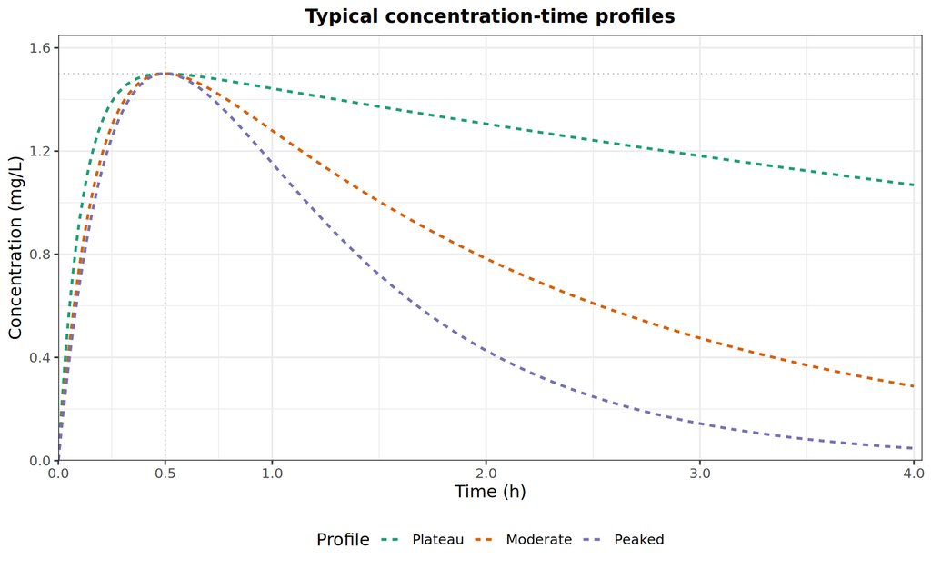

Concentration-time profiles for Plateau, Moderate and Peaked at the typical parameters, with no between-subject variability or residual error. Dotted reference lines mark 0.5 h and the common typical peak concentration of 1.5 mg/L.

### 3.1.3 Sampling schedules

Three sampling schedules are applied to the same per-subject time-courses, so each subject acts as its own control across schedules. A fourth analysis set, Predicted, keeps every minute of each subject’s individual predicted profile without residual error; it is the reference the schedules are measured against, not a schedule anyone could run:

The concentration analysis sets. The three sampling schedules and the Predicted set are all taken from the same simulated subjects, so every comparison is within-subject.

| Analysis set | Samples (0-24 h) | Sampling times (h) | Purpose |
| --- | --- | --- | --- |
| Planned | 13 | 0, 0.25, 0.5, 0.75, 1, 1.5, 2, 3, 4, 6, 8, 12, 24 | Reference schedule |
| Omission | 12 | Planned times with the 0.5 h sample dropped | Missed near-Tmax sample |
| Delay | 13 | Planned times, but the 0.5 h sample drawn at 0.667 h (+10 min) | Delayed near-Tmax sample |
| Predicted | 1441 | Every minute | Individual predicted profiles, without residual error |

The planned 13-sample schedule is the reference. The omission and delay schedules each alter the single 0.5 h near-peak sample: omission drops it, and delay replaces it with the draw at 0.667 h:

```r
# --- sampling schedules -----------------------------------------------------
planned <- profiles_sim |>
  filter(in_set(time, NOMINAL_TIMES)) |>
  transmute(PROFILE, ID, SCHEDULE = "planned",
            TIME_PLANNED = round(time, 6),
            TIME_ACTUAL  = round(time, 6),
            CONC = DV)

omission <- planned |>
  filter(!near(TIME_PLANNED, 0.5)) |>
  mutate(SCHEDULE = "omission")

delayed_sample <- profiles_sim |>
  filter(in_set(time, DELAY_TIME)) |>
  transmute(PROFILE, ID, SCHEDULE = "delay",
            TIME_PLANNED = 0.5,
            TIME_ACTUAL  = round(time, 6),
            CONC = DV)

delay <- bind_rows(
  planned |> filter(!near(TIME_PLANNED, 0.5)) |> mutate(SCHEDULE = "delay"),
  delayed_sample
) |> arrange(PROFILE, ID, TIME_ACTUAL)

obs <- bind_rows(planned, omission, delay)
```

## 3.2 NCA

NCA is performed with the R package `PKNCA`:

- **Endpoints:** Cmax, AUC0-t and AUC0-inf are primary; Tmax is secondary.
- **Sample times:** identical PKNCA settings for every analysis set, using actual collection times.
- **AUC:** linear-up / log-down trapezoidal rule, over the 0–last and 0–inf intervals.
- **Summaries:** geometric mean (geometric CV%) for exposure parameters and median (min–max) for Tmax.
- **Not applied:** no LLOQ was applied. AUC0-inf requires a terminal slope, so λz is estimated internally as a dependency, but terminal-phase parameters are not reported as study endpoints.

```r
# NCA interval: 0 to infinity. lambda.z is requested because aucinf.obs needs it.
NCA_INTERVAL <- data.frame(
  start      = 0,
  end        = Inf,
  cmax       = TRUE,
  tmax       = TRUE,
  auclast    = TRUE,
  aucinf.obs = TRUE,
  lambda.z   = TRUE
)

# Parameters reported: Cmax, Tmax, AUC0-t, AUC0-inf.
NCA_PARAMS_WIDE <- c("cmax", "tmax", "auclast", "aucinf.obs")

#' Run NCA on one sampling schedule across all (PROFILE, ID), at the actual sample times.
#'
#' @param obs       Long observation data (PROFILE, ID, SCHEDULE, TIME_*, CONC).
#' @param schedule  Schedule to subset ("planned", "omission", "delay").
#' @param run_label Label tagged onto the output (e.g. "PLANNED").
#' @return Long PKNCA result with RUN_LABEL attached.
run_nca_schedule <- function(obs, schedule, run_label) {
  stopifnot(schedule %in% unique(obs$SCHEDULE))

  sub <- obs %>%
    filter(SCHEDULE == schedule) %>%
    transmute(PROFILE, ID, TIME = TIME_ACTUAL, CONC) %>%
    arrange(PROFILE, ID, TIME)

  conc_obj <- PKNCAconc(sub, CONC ~ TIME | PROFILE + ID)
  dose_df <- sub %>% distinct(PROFILE, ID) %>% mutate(TIME = 0, DOSE = 1)
  dose_obj <- PKNCAdose(dose_df, DOSE ~ TIME | PROFILE + ID)

  pk_res <- pk.nca(PKNCAdata(conc_obj, dose_obj, intervals = NCA_INTERVAL))
  out <- as.data.frame(pk_res$result)
  out$RUN_LABEL <- run_label
  out
}
```

Each subject also has a **predicted value** for every parameter: the same NCA applied to that subject’s individual predicted concentrations (IPRED) at one-minute resolution, without residual error. Because a one-compartment oral model has closed forms for all four parameters, the predicted values are checked against them (Tmax = ln(ka/kel)/(ka − kel), AUC0-inf = dose/CL, and the corresponding expressions for Cmax and AUC0-24); they agree to within 0.03% on the exposures and half a minute on Tmax.

## 3.3 Statistical analysis

The analysis follows the SAP with documented amendments; changes made after results were available are identified in its dated amendment log. All comparisons are paired by subject.

The primary comparisons are Omission vs Planned and Delay vs Planned, within each profile shape (20 paired subjects). For each of the three ratio parameters (Cmax, AUC0-t, AUC0-inf), the per-subject ratio of the deviating schedule to the planned schedule is computed on the log scale and summarised as the geometric mean ratio with a 90% confidence interval from the paired *t*-distribution; 100% denotes no effect:

$$d_i = \ln\!\left(\frac{P_{\mathrm{test},i}}{P_{\mathrm{ref},i}}\right),
\qquad
\mathrm{GMR}\,(\%) = 100\,e^{\bar d}, \qquad
90\%\ \mathrm{CI}\,(\%) = 100\,\exp\!\left[\bar d \pm
t_{0.95,\,n-1}\,\frac{s_d}{\sqrt n}\right],$$

where $d_i$ is the log-ratio for subject $i$, $P$ is Cmax, AUC0-t or AUC0-inf, and $\bar d$ and $s_d$ are the mean and SD of the paired log-ratios. The spread of the individual ratios is summarised as the geometric CV of the paired ratios (from the SD of the log-ratios), the 5th–95th percentiles, and the minimum and maximum. As a secondary comparison, the planned schedule is compared with the predicted value on the same footing.

Tmax is summarised descriptively, as the distribution of recorded Tmax under each schedule, because it can only take one of the scheduled sampling times. The omission schedule has no 0.5 h sample, so the 25 of 60 profiles that peaked there under the planned schedule are forced elsewhere, so some of the shift is the gap itself.

The estimator takes the per-subject log-ratios, averages them, and back-transforms the mean and its paired-*t* interval to the ratio scale:

```r
#' GMR + 90% CI for the ratio parameters (paired log-scale estimator).
#' @return per (PROFILE, parameter, contrast): n, gmr, ci_lo, ci_hi.
gmr_summary <- function(pairs) {
  pairs %>%
    filter(parameter %in% PARAMS_RATIO,
           is.finite(theta_test), is.finite(theta_ref),
           theta_test > 0, theta_ref > 0) %>%
    group_by(PROFILE, parameter, contrast) %>%
    summarise(
      n            = n(),
      mean_logdiff = mean(log(theta_test) - log(theta_ref)),
      sd_logdiff   = sd(log(theta_test) - log(theta_ref)),
      .groups = "drop"
    ) %>%
    mutate(
      se        = sd_logdiff / sqrt(n),
      tcrit     = qt(0.95, n - 1),          # 90% CI
      gmr       = exp(mean_logdiff),
      ci_lo     = exp(mean_logdiff - tcrit * se),
      ci_hi     = exp(mean_logdiff + tcrit * se)
    ) %>%
    select(profile = PROFILE, parameter, contrast,
           n, gmr, ci_lo, ci_hi)
}
```

# 4 Results

## 4.1 Sampled concentrations

### 4.1.1 Simulated concentration-time profiles

The arithmetic means of the individual predictions (IPRED) across the 20 simulated subjects in each profile group are presented below. Between-subject variability is included, residual error is not. Peak mean concentrations slightly differ from the typical population peak mean (1.5 mg/L).

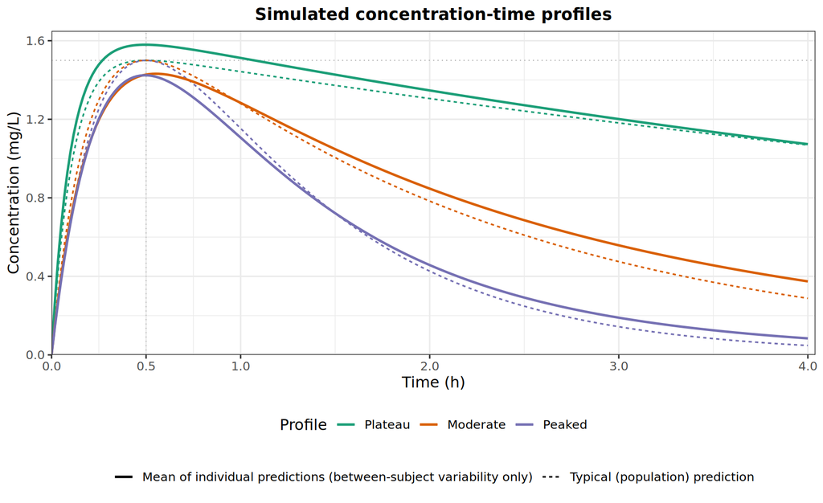

Solid lines are the mean of the individual predictions; dashed lines are the typical (population) predictions. Dotted reference lines mark 0.5 h and 1.5 mg/L.

### 4.1.2 Mean + SD profiles

The mean (+1 SD) of the simulated measurements, which include between-subject variability and residual error, is presented below.

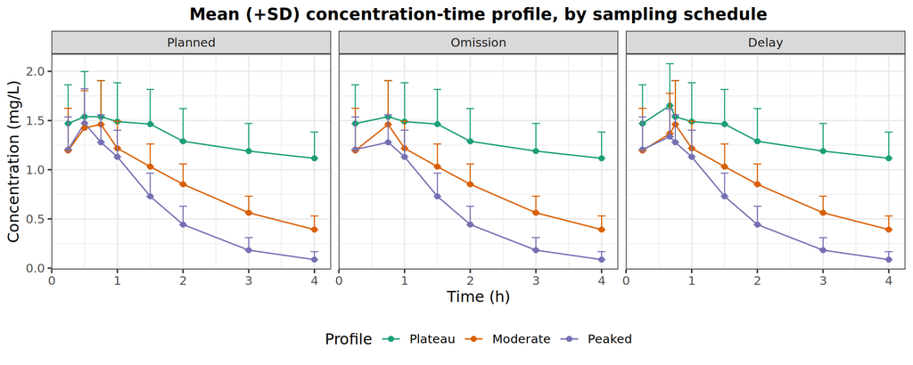

Mean (+1 SD) of the simulated measurements at each sampled time.

### 4.1.3 Individual profiles

Each panel shows one subject over 0-4 h. The dashed grey line is the typical (population) prediction, the solid colored line is the subject’s individual prediction (IPRED) without RUV, and the points are the simulated measurements, including residual error.

Common measurements are shown once. The open circle is the planned 0.5 h sample, and the triangle is the replacement drawn at 0.667 h. Omission removes the open circle; Delay replaces it with the triangle.

#### 4.1.3.1 Plateau

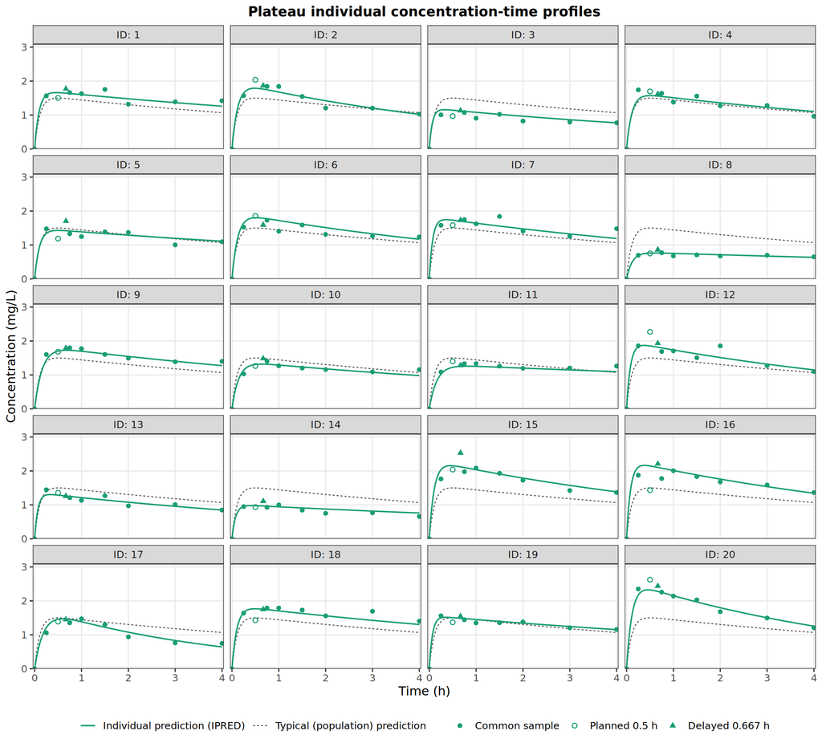

Plateau: individual concentration-time profiles. Open circles are the planned 0.5 h sample, which Omission removes; triangles are the replacement Delay draws at 0.667 h.

#### 4.1.3.2 Moderate

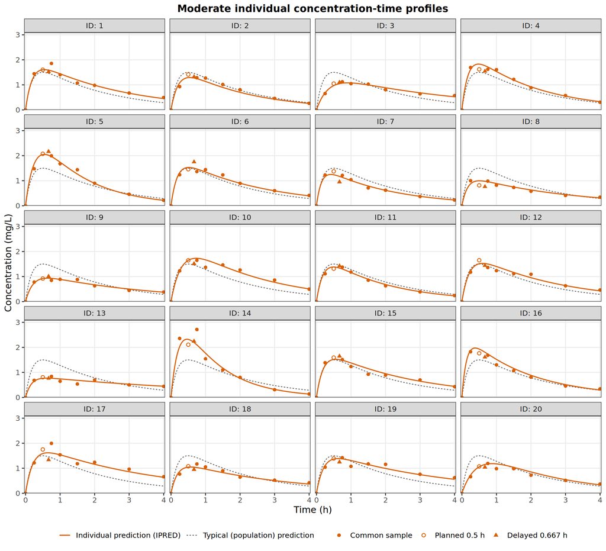

Moderate: individual concentration-time profiles. Open circles are the planned 0.5 h sample, which Omission removes; triangles are the replacement Delay draws at 0.667 h.

#### 4.1.3.3 Peaked

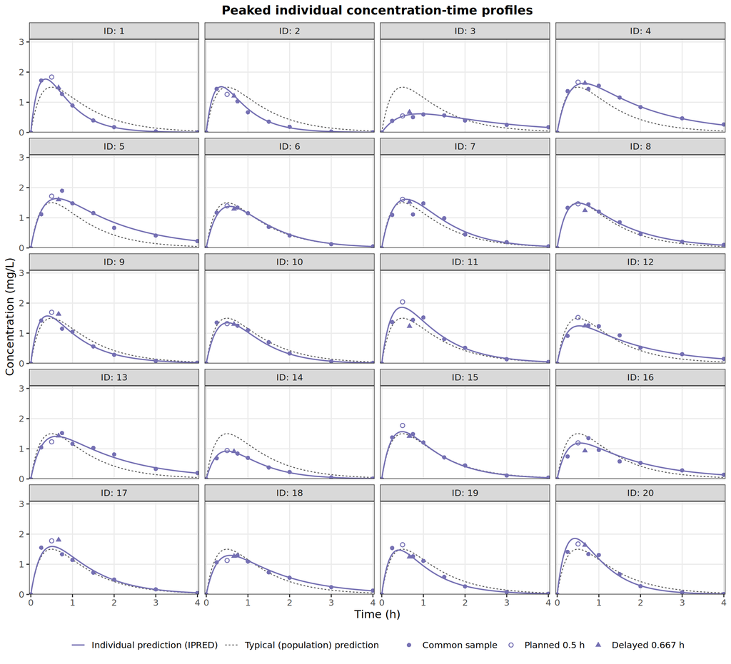

Peaked: individual concentration-time profiles. Open circles are the planned 0.5 h sample, which Omission removes; triangles are the replacement Delay draws at 0.667 h.

## 4.2 NCA

### 4.2.1 Parameter summary

Summary of NCA parameters by profile shape and sampling schedule, with each subject’s predicted value alongside

| Profile | Parameter | Planned | Omission | Delay | Predicted value |
| --- | --- | --- | --- | --- | --- |
| Plateau (N=20) | Cmax (mg/L) | 1.61 (29.6%) | 1.57 (27.2%) | 1.64 (26.7%) | 1.54 (27.8%) |
|  | Tmax (h) | 0.75 (0.25 - 1.50) | 0.75 (0.25 - 1.50) | 0.67 (0.25 - 1.50) | 0.47 (0.32 - 0.80) |
|  | AUC0-t (mg·h/L) | 13.8 (28.8%) | 13.8 (29.0%) | 13.8 (28.9%) | 13.9 (27.0%) |
|  | AUC0-inf (mg·h/L) | 15.6 (34.1%) | 15.6 (34.2%) | 15.7 (34.1%) | 15.6 (32.1%) |
| Moderate (N=20) | Cmax (mg/L) | 1.46 (29.6%) | 1.42 (29.8%) | 1.46 (29.8%) | 1.40 (29.0%) |
|  | Tmax (h) | 0.62 (0.25 - 0.75) | 0.75 (0.25 - 1.00) | 0.67 (0.25 - 0.75) | 0.55 (0.38 - 0.90) |
|  | AUC0-t (mg·h/L) | 4.34 (21.6%) | 4.31 (21.6%) | 4.30 (21.6%) | 4.39 (20.4%) |
|  | AUC0-inf (mg·h/L) | 4.34 (21.7%) | 4.32 (21.6%) | 4.31 (21.7%) | 4.40 (20.5%) |
| Peaked (N=20) | Cmax (mg/L) | 1.48 (27.7%) | 1.37 (25.3%) | 1.42 (23.7%) | 1.41 (25.9%) |
|  | Tmax (h) | 0.50 (0.25 - 1.00) | 0.75 (0.25 - 1.00) | 0.67 (0.25 - 1.00) | 0.52 (0.35 - 0.92) |
|  | AUC0-t (mg·h/L) | 2.33 (27.7%) | 2.27 (28.1%) | 2.29 (27.3%) | 2.38 (27.0%) |
|  | AUC0-inf (mg·h/L) | 2.33 (27.7%) | 2.27 (28.1%) | 2.29 (27.3%) | 2.38 (27.0%) |

Geometric mean (geometric CV%) is reported for all PK parameters, except Tmax which is summarised as median (min - max). The predicted value is the same NCA applied to each subject’s individual predicted profile (no residual error).

### 4.2.2 Tmax (secondary)

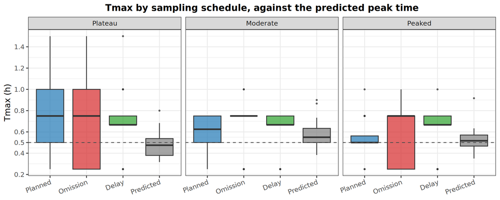

Boxes span the interquartile range. A recorded Tmax can only take one of the scheduled sampling times. The predicted value is calculated from each subject’s individual predicted concentrations (no residual error).

Compared with the predicted value, the median recorded Tmax was later under all three schedules in every profile, except the planned schedule in the Peaked profile (0.50 h vs 0.52 h predicted).

## 4.3 Statistical analysis

### 4.3.1 Geometric mean ratios

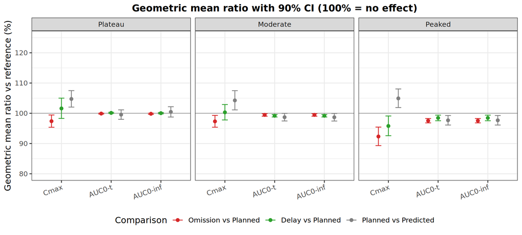

Geometric mean ratio (test ÷ reference) with 90% CI; 100% denotes no effect. The predicted value is calculated from each subject’s individual predicted concentrations (no residual error).

The forest plot and tables report each geometric mean ratio with its 90% CI, by parameter and profile shape. A missed near-peak sample lowered Cmax by 2.6-7.7% across the three shapes (geometric mean ratio 92.32%-97.38%), most in the Peaked profile, and lowered AUC0-t by 0.1-2.5% and AUC0-inf by 0.2-2.5%. A delayed sample, analysed at its actual draw time, changed Cmax by −4.2% to +1.6% (geometric mean ratio 95.79%-101.59%) and both AUCs by −1.5% to +0.1%.

These ratios span several parameters and profile shapes and are read as ranges describing magnitude, not as multiplicity-controlled tests.

The third comparison measures what a complete, well-placed schedule costs against the predicted value. The planned schedule brackets the peak by design (0.5 h is a scheduled time), yet it still returned a Cmax 104.26%-104.92% of the predicted value, higher by 4.3-4.9%. Almost none of that is a missed peak, and what there is runs the other way: taking the same 13 samples from the noise-free curve gives 98.83%-99.66% of the predicted Cmax, so the sampling grid *loses* about 0.3-1.2%. The overshoot is residual variability. Cmax is the largest of the measurements taken around the peak, and the largest of several draws with residual error sits above the concentration they are measuring, by enough to more than cancel the grid’s loss. AUC is not subject to that maximum selection, because a trapezoidal integral averages across all the measurements. Planned AUC0-t was 97.68%-99.55% of the predicted value and AUC0-inf 97.68%-100.45%. Those differences reflect the combined effects of sampling and residual error under the chosen NCA method, and AUC0-inf also depends on the estimated terminal slope.

#### 4.3.1.1 GMR tables

##### 4.3.1.1.1 Omission vs Planned

Omission vs Planned - geometric mean ratio (test ÷ reference) with 90% CI. 100% denotes no effect. Primary comparison versus the planned schedule.

| Parameter | Profile | GMR (%) | 90% CI (%) |
| --- | --- | --- | --- |
| Cmax | Plateau | 97.38 | 95.37 - 99.44 |
|  | Moderate | 97.32 | 95.39 - 99.29 |
|  | Peaked | 92.32 | 89.32 - 95.43 |
| AUC0-t | Plateau | 99.90 | 99.74 - 100.06 |
|  | Moderate | 99.46 | 99.03 - 99.89 |
|  | Peaked | 97.54 | 96.82 - 98.26 |
| AUC0-inf | Plateau | 99.83 | 99.64 - 100.02 |
|  | Moderate | 99.46 | 99.03 - 99.89 |
|  | Peaked | 97.54 | 96.82 - 98.26 |

##### 4.3.1.1.2 Delay vs Planned

Delay vs Planned - geometric mean ratio (test ÷ reference) with 90% CI. 100% denotes no effect. Primary comparison versus the planned schedule.

| Parameter | Profile | GMR (%) | 90% CI (%) |
| --- | --- | --- | --- |
| Cmax | Plateau | 101.59 | 98.30 - 105.00 |
|  | Moderate | 100.30 | 97.79 - 102.88 |
|  | Peaked | 95.79 | 92.59 - 99.11 |
| AUC0-t | Plateau | 100.13 | 99.95 - 100.31 |
|  | Moderate | 99.18 | 98.77 - 99.60 |
|  | Peaked | 98.46 | 97.53 - 99.39 |
| AUC0-inf | Plateau | 100.04 | 99.82 - 100.25 |
|  | Moderate | 99.19 | 98.77 - 99.60 |
|  | Peaked | 98.46 | 97.53 - 99.39 |

##### 4.3.1.1.3 Planned vs Predicted

Planned vs Predicted - geometric mean ratio (test ÷ reference) with 90% CI. 100% denotes no effect. Secondary comparison.

| Parameter | Profile | GMR (%) | 90% CI (%) |
| --- | --- | --- | --- |
| Cmax | Plateau | 104.73 | 102.04 - 107.50 |
|  | Moderate | 104.26 | 101.12 - 107.49 |
|  | Peaked | 104.92 | 101.89 - 108.04 |
| AUC0-t | Plateau | 99.55 | 97.99 - 101.13 |
|  | Moderate | 98.70 | 97.46 - 99.96 |
|  | Peaked | 97.68 | 96.11 - 99.27 |
| AUC0-inf | Plateau | 100.45 | 98.76 - 102.17 |
|  | Moderate | 98.68 | 97.44 - 99.93 |
|  | Peaked | 97.68 | 96.11 - 99.27 |

### 4.3.2 Individual-subject ratios

The GMR describes the average subject; a data query or an outlier assessment concerns one subject. The figure shows the individual ratios behind all three comparisons, coloured as in the forest plot, and the table summarizes their spread.

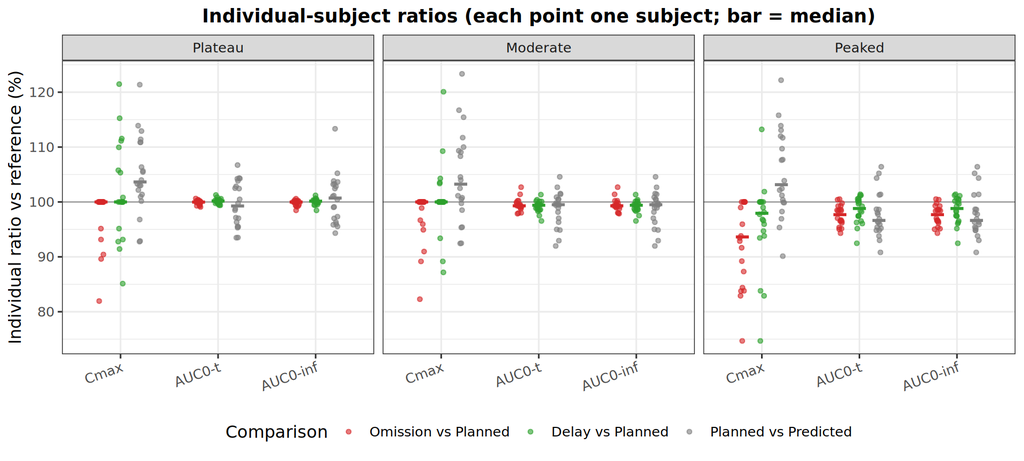

Individual-subject ratios (test ÷ reference). Each point is one subject; the bar is the median. Omission and Delay vs Planned are primary comparisons; Planned vs Predicted is secondary.

Spread of the individual ratios (test ÷ reference). Omission and Delay vs Planned are primary; Planned vs Predicted is secondary.

| Comparison | Parameter | Profile | GMR (%) | Geometric CV of ratio (%) | 5th - 95th pct (%) | Min - max (%) |
| --- | --- | --- | --- | --- | --- | --- |
| Omission vs Planned | Cmax | Plateau | 97.4 | 5.4 | 89.2 - 100.0 | 81.9 - 100.0 |
|  |  | Moderate | 97.3 | 5.2 | 88.8 - 100.0 | 82.3 - 100.0 |
|  |  | Peaked | 92.3 | 8.6 | 82.5 - 100.0 | 74.7 - 100.0 |
|  | AUC0-t | Plateau | 99.9 | 0.4 | 99.3 - 100.4 | 99.1 - 100.6 |
|  |  | Moderate | 99.5 | 1.1 | 98.0 - 101.5 | 97.9 - 102.7 |
|  |  | Peaked | 97.5 | 1.9 | 95.0 - 100.4 | 94.3 - 100.5 |
|  | AUC0-inf | Plateau | 99.8 | 0.5 | 99.1 - 100.4 | 98.5 - 100.6 |
|  |  | Moderate | 99.5 | 1.1 | 98.0 - 101.5 | 97.9 - 102.7 |
|  |  | Peaked | 97.5 | 1.9 | 95.0 - 100.4 | 94.3 - 100.5 |
| Delay vs Planned | Cmax | Plateau | 101.6 | 8.5 | 91.1 - 115.6 | 85.1 - 121.5 |
|  |  | Moderate | 100.3 | 6.6 | 89.1 - 109.8 | 87.2 - 120.1 |
|  |  | Peaked | 95.8 | 8.8 | 82.5 - 102.4 | 74.7 - 113.2 |
|  | AUC0-t | Plateau | 100.1 | 0.5 | 99.4 - 100.9 | 99.4 - 101.3 |
|  |  | Moderate | 99.2 | 1.1 | 97.5 - 100.5 | 96.5 - 101.3 |
|  |  | Peaked | 98.5 | 2.4 | 95.0 - 101.2 | 92.5 - 101.4 |
|  | AUC0-inf | Plateau | 100.0 | 0.6 | 99.4 - 100.7 | 98.5 - 101.2 |
|  |  | Moderate | 99.2 | 1.1 | 97.5 - 100.5 | 96.5 - 101.3 |
|  |  | Peaked | 98.5 | 2.4 | 95.0 - 101.2 | 92.5 - 101.4 |
| Planned vs Predicted | Cmax | Plateau | 104.7 | 6.7 | 92.9 - 114.3 | 92.8 - 121.4 |
|  |  | Moderate | 104.3 | 7.9 | 92.5 - 117.0 | 92.4 - 123.3 |
|  |  | Peaked | 104.9 | 7.6 | 95.1 - 116.1 | 90.1 - 122.2 |
|  | AUC0-t | Plateau | 99.5 | 4.1 | 93.5 - 104.5 | 93.5 - 106.7 |
|  |  | Moderate | 98.7 | 3.3 | 92.9 - 102.8 | 92.0 - 104.6 |
|  |  | Peaked | 97.7 | 4.2 | 92.9 - 105.3 | 90.8 - 106.4 |
|  | AUC0-inf | Plateau | 100.5 | 4.4 | 95.5 - 105.6 | 94.3 - 113.3 |
|  |  | Moderate | 98.7 | 3.3 | 92.9 - 102.8 | 92.0 - 104.6 |
|  |  | Peaked | 97.7 | 4.2 | 92.9 - 105.3 | 90.8 - 106.4 |

For Cmax after a missed near-peak sample, the geometric CV of the paired ratios was 5.2-8.6% and the lowest single-subject ratio was 74.7% of planned (5th percentile 82.47%-89.22% across profile shapes). After a delayed sample the single-subject Cmax ratios ranged from 74.7% to 121.5%, the widest individual spread of any comparison, because a sample 10 min later can fall on either side of a peak blurred by residual error. The AUC ratios were far tighter: in the primary comparisons no individual AUC0-t or AUC0-inf ratio fell below 92.5% or above 102.7%. Against the predicted value (grey), the individual ratios fall on both sides of 100% for every parameter; no sample was missed or moved, so this scatter is residual variability. For Cmax the median is above 100% in all three profiles.

## 4.4 Results Summary

The objective was to quantify how much a single missed or delayed sample around Tmax biases the key NCA exposure parameters (Cmax, AUC0-t, AUC0-inf) relative to a planned schedule, and secondarily to characterize how simulated variability affects Cmax and Tmax. The main findings were:

1. Missing or delayed samples had their largest impact on Cmax, a decrease that was greatest in the sharply peaked profile.
2. Residual variability made the observed Cmax higher than the predicted Cmax, even when every sample was collected on time.

Across the three profile shapes:

**Effect on Cmax.**

- Omission vs Planned: Cmax was 92.32%-97.38% of planned (lower by 2.6-7.7%). This was the largest effect of either deviation, because dropping the near-peak sample widens the gap between the sampled maximum and the predicted peak; the sharper the peak, the larger the loss.
- Delay vs Planned: Cmax was 95.79%-101.59% of planned (a change of −4.2% to +1.6%); the sample drawn 10 min late still lands near the peak, and on the Plateau profile can even exceed the 0.5 h value.
- Individual subjects: the single-subject Cmax ratio fell as low as 74.7% after a missed sample, and ranged from 74.7% to 121.5% after a delayed one.
- Against the predicted value: even with every sample collected on time, residual variability made the observed Cmax 4.3-4.9% higher than the predicted Cmax.

**Effect on AUC (AUC0-t and AUC0-inf).**

- Omission lowered AUC0-t by 0.1-2.5% and AUC0-inf by 0.2-2.5%; delay moved both by −1.5% to +0.1%. The largest absolute change in any of those geometric mean ratios was 2.5% (Peaked profile, omission). No individual subject’s AUC ratio fell outside 92.5%–102.7%; one near-peak point is a small part of the exposure integral.

**Effect on Tmax.**

- Omission moved the recorded Tmax to another scheduled time for 5, 7 and 13 of 20 subjects (Plateau, Moderate, Peaked): the subjects whose peak had been recorded at the missing 0.5 h sample. The replacement was not always the neighbouring time, and was sometimes earlier. Delay recorded Tmax at the +10 min draw whenever that sample was the largest measurement.

# 5 Discussion

Single-dose concentration–time data were simulated from three one-compartment oral PK models, ranging from slow elimination with a flat plateau to fast elimination with a sharp peak. Three sampling schedules were applied to the same subjects, NCA parameters were derived from each, and each deviating schedule was compared with the planned schedule as a paired geometric mean ratio with a 90% confidence interval.

- **Cmax.** A missed near-peak sample produced the largest change, lowering Cmax by 2.6-7.7% on average; a sample drawn 10 min late changed it by −4.2% to +1.6%. The loss grows with peak sharpness, so it is the Peaked (fast-elimination) profile that is most exposed. These ratios are relative to the planned practical schedule, and they assume the deviation falls on the near-Tmax sample; a deviation elsewhere on the curve would affect Cmax less. The delay result also assumes the actual draw time is recorded and used in the analysis; a delayed sample analysed at its planned time would behave differently and was not studied here.
- **Individual subjects.** The mean effect understates what can happen to one subject: the lowest single-subject Cmax ratio after a missed sample was 74.7% of planned. For a study-level GMR a single deviating subject contributes only its share of the mean, but for a single-subject data query or an outlier assessment the individual ratio is the relevant quantity.
- **AUC.** The largest absolute change in any AUC0-t or AUC0-inf geometric mean ratio under either deviation was 2.5% (Peaked profile, omission), because a single near-peak point is a small fraction of the integral. These results do not establish the effects of deviations at other times or of multiple missing samples.
- **Tmax.** Omission shifts the recorded Tmax to whichever remaining sample is largest, and delay can shift it to the later draw, so Tmax tracks the sampling times directly rather than the underlying peak. It also ran later than the real peak time with no deviation at all: on the Plateau profile the median predicted Tmax is 0.47 h, but the planned schedule recorded 0.75 h. Two explanations are consistent with that: the schedule can only report a time it sampled, and on a flat, slowly-declining peak many time points sit within residual error of the maximum, so the largest measurement can land on any of them. This study did not separate the two contributions. Observed Tmax should therefore be read as approximate.
- **A complete schedule still overstates Cmax.** Compared with each subject’s predicted value, the planned schedule returned a Cmax higher by 4.3-4.9%, even though 0.5 h is a scheduled sample and the peak is bracketed by design. Two effects run against each other and residual variability wins: sampling at 13 points rather than continuously loses 0.3-1.2% of the peak, while Cmax being a maximum over measurements with residual error adds more than that back. The upward component grows with the number of samples near the peak, the opposite direction to the loss from a missed sample. It is also a reason to read an absolute Cmax more cautiously than a within-study Cmax ratio. AUC is not subject to maximum selection: AUC0-t came out 97.68%-99.55% of the predicted value and AUC0-inf 97.68%-100.45%.

**Other limitations.**

- A single delay magnitude (+10 min on the 0.5 h sample), a single missed sample, and 20 subjects per profile were studied. Larger delays, multiple deviations, deviations at later time points, and a coarser schedule around the peak (the planned schedule samples every 15 min from 0.25 to 1 h, denser than many Phase 1 designs) would give different numbers.
- No lower limit of quantification was applied, and sensitivity to BLQ handling was not evaluated. Applying an LLOQ could move the last quantifiable sample earlier, changing AUC0-t and potentially the terminal fit and the AUC0-inf extrapolation. The small extrapolated tail under the current analysis does not establish insensitivity to those changes. Terminal parameters are estimated internally as needed for AUC0-inf but are not reported as study endpoints.
- The reference for the primary comparisons is the planned practical schedule, so those ratios are “deviating vs planned schedule”. The separate comparison against each subject’s predicted value is what places the planned schedule itself.